# Tidy Models with Broom

2/24/2020

## The `broom` package

Although most functions use data in a tidy format for input, often the output is messy.

```r
head(mtcars)
```

```
##                    mpg cyl disp  hp drat    wt  qsec vs am gear carb
## Mazda RX4         21.0   6  160 110 3.90 2.620 16.46  0  1    4    4
## Mazda RX4 Wag     21.0   6  160 110 3.90 2.875 17.02  0  1    4    4
## Datsun 710        22.8   4  108  93 3.85 2.320 18.61  1  1    4    1
## Hornet 4 Drive    21.4   6  258 110 3.08 3.215 19.44  1  0    3    1
## Hornet Sportabout 18.7   8  360 175 3.15 3.440 17.02  0  0    3    2
## Valiant           18.1   6  225 105 2.76 3.460 20.22  1  0    3    1
```

```r
fit <- lm(mpg ~ wt + qsec, data = mtcars)
fit
```

```
##
## Call:
## lm(formula = mpg ~ wt + qsec, data = mtcars)
##
## Coefficients:
## (Intercept)           wt         qsec
##     19.7462      -5.0480       0.9292
```

```r
summary(fit)
```

```
##
## Call:
## lm(formula = mpg ~ wt + qsec, data = mtcars)
##
## Residuals:
##     Min      1Q  Median      3Q     Max
## -4.3962 -2.1431 -0.2129  1.4915  5.7486
##
## Coefficients:
##             Estimate Std. Error t value Pr(>|t|)
## (Intercept)  19.7462     5.2521   3.760 0.000765 ***
## wt           -5.0480     0.4840 -10.430 2.52e-11 ***
## qsec          0.9292     0.2650   3.506 0.001500 **
## ---
## Signif. codes:  0 '***' 0.001 '**' 0.01 '*' 0.05 '.' 0.1 ' ' 1
##
## Residual standard error: 2.596 on 29 degrees of freedom
## Multiple R-squared:  0.8264, Adjusted R-squared:  0.8144
## F-statistic: 69.03 on 2 and 29 DF,  p-value: 9.395e-12
```

That is, the output is easy for humans to read but not for computers.

[figure not shown]

`summary(fit)` contains

- coefficient-level information, including the estimate, standard error, and p-value, about each of the intercept, `wt`, and `qsec` terms.
- observation-level information, such as the residuals and fitted values
- model-level information in the form of \(R^2\), adjusted \(R^2\), an F statistic, and a p-value for the whole dataset.

The `broom` package contains three functions to generate corresponding data frames:

- `tidy()`—component level
- `augment()`—observation level
- `glance()`—model level

```r
library(broom)
tidy(fit)
```

```
## # A tibble: 3 x 5
##   term        estimate std.error statistic  p.value
##   <chr>          <dbl>     <dbl>     <dbl>    <dbl>
## 1 (Intercept)   19.7       5.25       3.76 7.65e- 4
## 2 wt            -5.05      0.484    -10.4  2.52e-11
## 3 qsec           0.929     0.265      3.51 1.50e- 3
```

```r
class(tidy(fit))
```

```
## [1] "tbl_df"     "tbl"        "data.frame"
```

```r
head(augment(fit))
```

```
## # A tibble: 6 x 11
##   .rownames   mpg    wt  qsec .fitted .se.fit  .resid   .hat .sigma .cooksd
##   <chr>     <dbl> <dbl> <dbl>   <dbl>   <dbl>   <dbl>  <dbl>  <dbl>   <dbl>
## 1 Mazda RX4  21    2.62  16.5    21.8   0.683 -0.815  0.0693   2.64 2.63e-3
## 2 Mazda RX…  21    2.88  17.0    21.0   0.547 -0.0482 0.0444   2.64 5.59e-6
## 3 Datsun 7…  22.8  2.32  18.6    25.3   0.640 -2.53   0.0607   2.60 2.17e-2
## 4 Hornet 4…  21.4  3.22  19.4    21.6   0.623 -0.181  0.0576   2.64 1.05e-4
## 5 Hornet S…  18.7  3.44  17.0    18.2   0.512  0.504  0.0389   2.64 5.29e-4
## 6 Valiant    18.1  3.46  20.2    21.1   0.803 -2.97   0.0957   2.58 5.10e-2
## # … with 1 more variable: .std.resid <dbl>
```

```r
glance(fit)
```

```
## # A tibble: 1 x 11
##   r.squared adj.r.squared sigma statistic  p.value    df logLik   AIC   BIC
##       <dbl>         <dbl> <dbl>     <dbl>    <dbl> <int>  <dbl> <dbl> <dbl>
## 1     0.826         0.814  2.60      69.0 9.39e-12     3  -74.4  157.  163.
## # … with 2 more variables: deviance <dbl>, df.residual <int>
```

- The `broom` package works with various methods, including `lm()`, `glm()`, and `t.test()`. Not all the broom functions make sense in all contexts (e.g., `augment()` with `t.test()`).
- I find the `broom` package most useful when I’ve got more steps in my analyses. E.g.,
  - I’m fitting several models to the same data and want to create a single table of coefficients and such
  - I’m fitting the same model to subgroups.

## Using `broom` for subgroup analyses

```r
# The do() function from dplyr allows for any computation and returns a data frame
regressions <- mtcars %>%
  group_by(am) %>%
    do(tidy(lm(mpg ~ wt + qsec, data = .), conf.int = TRUE))
regressions
```

```
## # A tibble: 6 x 8
## # Groups:   am [2]
##      am term        estimate std.error statistic p.value conf.low conf.high
##   <dbl> <chr>          <dbl>     <dbl>     <dbl>   <dbl>    <dbl>     <dbl>
## 1     0 (Intercept)   11.2       6.71       1.68 1.13e-1  -2.99       25.5
## 2     0 wt            -3.00      0.664     -4.52 3.52e-4  -4.40       -1.59
## 3     0 qsec           0.945     0.295      3.21 5.46e-3   0.321       1.57
## 4     1 (Intercept)   20.2      11.2        1.80 1.02e-1  -4.78       45.1
## 5     1 wt            -6.75      1.43      -4.72 8.15e-4  -9.94       -3.57
## 6     1 qsec           1.18      0.492      2.40 3.74e-2   0.0837      2.28
```

<sup>Examples from Robinson, D. (2014). broom: An R Package for Converting Statistical Analysis Objects Into Tidy Data Frames. arXiv preprint arXiv:1412.3565.</sup>

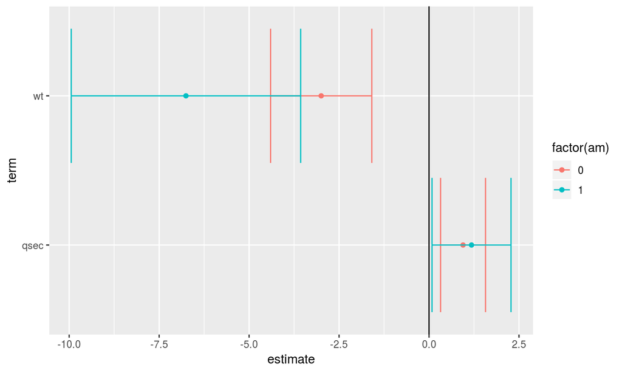

```r
regressions %>% filter(term != "(Intercept)") %>%
    ggplot(aes(x = estimate, y = term, color = factor(am))) +
    geom_point() + geom_errorbarh(aes(xmin = conf.low, xmax = conf.high)) +
    geom_vline(xintercept = 0)
```

Let’s look at an example from the `broom` paper

```r
library(Lahman)
merged <- Batting %>% as_tibble() %>%
    inner_join(Salaries) %>%
    mutate(average = H / AB) %>%
    filter(salary > 0, AB >= 500, !(playerID %in% Pitching$playerID))
glimpse(merged)
```

```
## Observations: 2,811
## Variables: 24
## $ playerID <chr> "backmwa01", "baineha01", "balbost01", "barfije01", "ba…
## $ yearID   <int> 1985, 1985, 1985, 1985, 1985, 1985, 1985, 1985, 1985, 1…
## $ stint    <int> 1, 1, 1, 1, 1, 1, 1, 1, 1, 1, 1, 1, 1, 1, 1, 1, 1, 1, 1…
## $ teamID   <chr> "NYN", "CHA", "KCA", "TOR", "BOS", "HOU", "TOR", "CLE",…
## $ lgID     <chr> "NL", "AL", "AL", "AL", "AL", "NL", "AL", "AL", "AL", "…
## $ G        <int> 145, 160, 160, 155, 156, 150, 157, 153, 159, 155, 156, …
## $ AB       <int> 520, 640, 600, 539, 534, 539, 607, 500, 641, 550, 605, …
## $ R        <int> 77, 86, 74, 94, 59, 72, 87, 73, 100, 108, 67, 71, 89, 1…
## $ H        <int> 142, 198, 146, 156, 142, 145, 167, 137, 192, 184, 163, …
## $ X2B      <int> 24, 29, 28, 34, 26, 27, 28, 26, 33, 38, 34, 28, 46, 28,…
## $ X3B      <int> 5, 3, 2, 9, 0, 5, 6, 3, 8, 5, 7, 4, 3, 14, 1, 2, 10, 8,…
## $ HR       <int> 1, 22, 36, 27, 5, 16, 28, 11, 26, 30, 13, 27, 16, 5, 32…
## $ RBI      <int> 38, 113, 88, 84, 56, 68, 95, 59, 88, 112, 100, 90, 110,…
## $ SB       <int> 30, 1, 1, 22, 7, 19, 21, 17, 22, 9, 6, 5, 18, 47, 1, 1,…
## $ CS       <int> 12, 1, 1, 8, 5, 8, 6, 9, 9, 1, 9, 3, 4, 20, 1, 1, 25, 3…
## $ BB       <int> 36, 42, 52, 66, 56, 31, 43, 69, 55, 103, 34, 71, 30, 63…
## $ SO       <int> 72, 89, 166, 143, 50, 63, 90, 72, 129, 49, 79, 86, 36, …
## $ IBB      <int> 1, 8, 4, 5, 3, 1, 6, 2, 4, 31, 6, 7, 5, 2, 16, 9, 1, 3,…
## $ HBP      <int> 1, 1, 5, 4, 2, 6, 8, 1, 12, 3, 5, 0, 2, 1, 6, 4, 0, 2, …
## $ SH       <int> 14, 0, 0, 0, 12, 4, 0, 5, 4, 0, 0, 0, 2, 8, 0, 0, 5, 1,…
## $ SF       <int> 3, 10, 5, 3, 4, 2, 8, 4, 2, 9, 8, 13, 11, 3, 3, 2, 1, 1…
## $ GIDP     <int> 3, 23, 14, 14, 14, 10, 8, 11, 14, 12, 20, 12, 16, 8, 18…
## $ salary   <int> 200000, 675000, 205000, 325000, 272500, 155000, 335000,…
## $ average  <dbl> 0.2730769, 0.3093750, 0.2433333, 0.2894249, 0.2659176, …
```

Look at a single linear regression of log of salary against batting average, controlling for year.

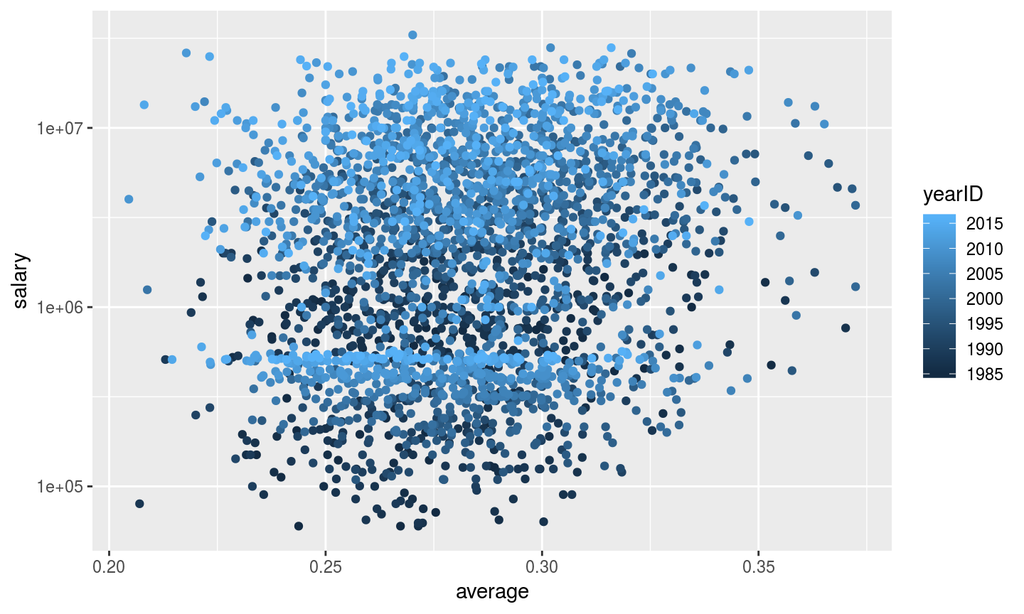

```r
ggplot(merged, aes(average, salary, color = yearID)) +
  geom_point() +
  scale_y_log10()
```

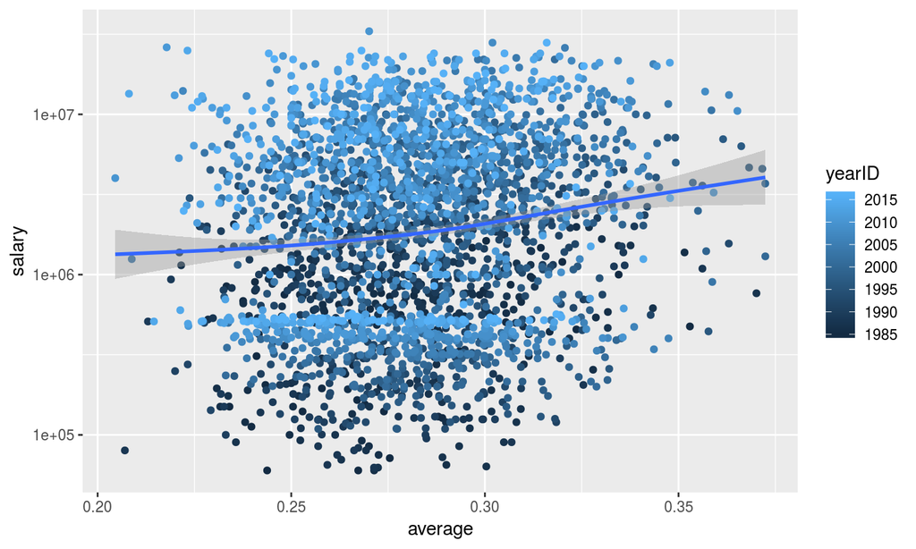

```r
ggplot(merged, aes(average, salary, color = yearID)) +
  geom_point() +
  scale_y_log10() +
  geom_smooth()
```

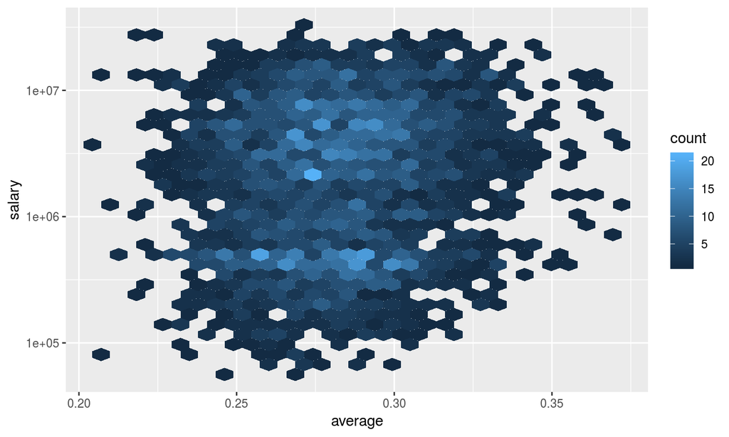

```r
ggplot(merged, aes(average, salary, color = yearID)) +
  geom_hex() +
  scale_y_log10()
```

```r
salary_fit <- lm(log10(salary) ~ average + yearID, merged)
summary(salary_fit)
```

```
##
## Call:
## lm(formula = log10(salary) ~ average + yearID, data = merged)
##
## Residuals:
##     Min      1Q  Median      3Q     Max
## -1.1200 -0.4686  0.1338  0.4322  1.0909
##
## Coefficients:
##               Estimate Std. Error t value Pr(>|t|)
## (Intercept) -51.556468   2.256190 -22.851   <2e-16 ***
## average       3.363662   0.385683   8.721   <2e-16 ***
## yearID        0.028419   0.001124  25.275   <2e-16 ***
## ---
## Signif. codes:  0 '***' 0.001 '**' 0.01 '*' 0.05 '.' 0.1 ' ' 1
##
## Residual standard error: 0.5374 on 2808 degrees of freedom
## Multiple R-squared:  0.2001, Adjusted R-squared:  0.1996
## F-statistic: 351.3 on 2 and 2808 DF,  p-value: < 2.2e-16
```

Could this vary by team?

```r
team_regressions <- merged %>% group_by(teamID) %>%
    do(tidy(lm(log10(salary) ~ average + yearID, .), conf.int = TRUE))
team_regressions
```

```
## # A tibble: 105 x 8
## # Groups:   teamID [35]
##    teamID term      estimate std.error statistic p.value conf.low conf.high
##    <chr>  <chr>        <dbl>     <dbl>     <dbl>   <dbl>    <dbl>     <dbl>
##  1 ANA    (Interc… -87.8      83.4        -1.05  0.300   -2.58e+2   82.2
##  2 ANA    average    3.51      3.97        0.885 0.383   -4.58e+0   11.6
##  3 ANA    yearID     0.0465    0.0417      1.12  0.273   -3.86e-2    0.132
##  4 ARI    (Interc…  12.1      24.3         0.495 0.622   -3.66e+1   60.7
##  5 ARI    average    1.02      2.78        0.368 0.715   -4.54e+0    6.59
##  6 ARI    yearID    -0.00301   0.0121     -0.249 0.804   -2.72e-2    0.0212
##  7 ATL    (Interc… -29.7      12.4        -2.40  0.0181  -5.42e+1   -5.19
##  8 ATL    average    1.33      2.09        0.634 0.527   -2.82e+0    5.48
##  9 ATL    yearID     0.0178    0.00616     2.89  0.00472  5.59e-3    0.0300
## 10 BAL    (Interc… -32.9      10.4        -3.16  0.00207 -5.36e+1  -12.3
## # … with 95 more rows
```

It’s now easy to examine the results visually.

```r
coefs <- team_regressions %>% ungroup() %>%
    filter(term == "average") %>%
    mutate(teamID = reorder(teamID, estimate))
```

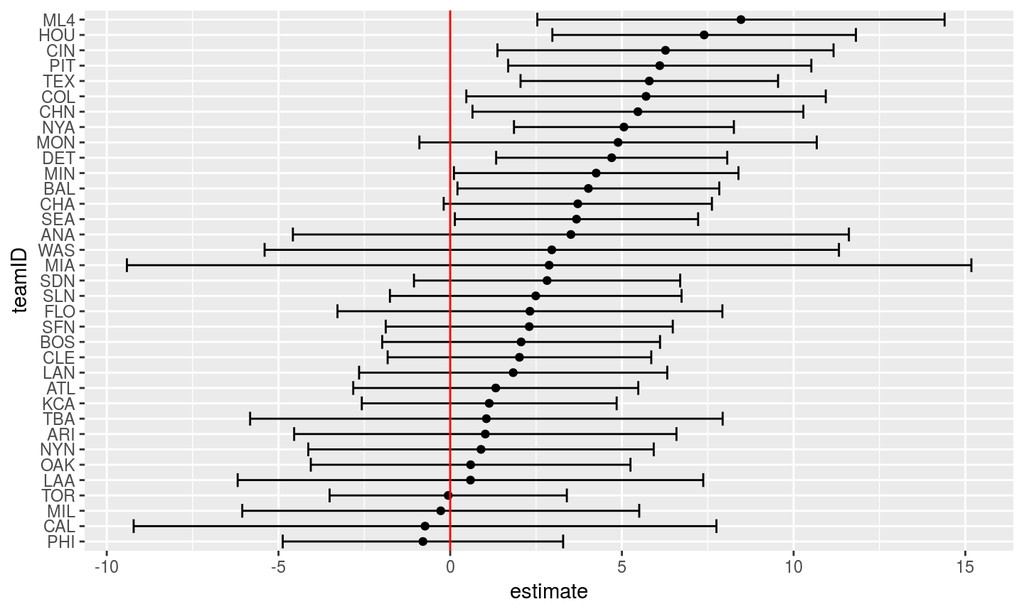

```r
ggplot(coefs, aes(x = estimate, y = teamID)) + geom_point() +
    geom_errorbarh(aes(xmin = conf.low, xmax = conf.high)) +
    geom_vline(xintercept = 0, color = "red")
```

## In class exercises

- Using the `gapminder` dataset, try the `tidy()`, `augment()`, and `glance()` on the following regression:
  - `lm(lifeExp ~ log10(gdpPercap), data = gapminder))`
- Group the regressions by year; make both a data frame of the slope of the regression line and associated values and then try plotting the coefficients.